# Laptops

5/1/2020

```r
library(readr)
library(tidyverse)
library(mosaic)
library(car)
library(pander)
library(DT)


Laptop <- read_csv("laptops.csv")

laptop.idp <- Laptop %>%
  filter(str_detect(Product, "Ideapad|IdeaPad|ideapad"))

idp2 <- laptop.idp %>% mutate(wt = parse_number(Weight))
```

## Question 1

**What is a residual? What use does a single residual provide within a regression analysis?**

A residual is a distance, which is calculated by taking the observed value of Y and subtracting off the Predicted value of Y. It can be demonstrated as such:
$$\underbrace{r_i}_\text{Residual Value}=\underbrace{Y_i}_\text{Observed Y-value} -\underbrace{\hat{Y_i}}_\text{Predicted Y- Value}$$
Where $r_i$ is the residual value for individual $i$. A residual is the sample statistic that estimates the true (typically unknown) value of an error, which is the observed value of Y minus the true mean Y- value, or in mathematical terms:
$$\underbrace{\epsilon_i}_\text{Residual Value}=\underbrace{Y_i}_\text{Observed Y-value} -\underbrace{E\{Y_i\}}_{\substack{\text{True Mean} \\ \text{Y-value}}}$$

The residual of a certain point on the following graph, which corresponds to a laptop with weight of 3.49 kilograms and a cost of 2813.75 euros is shown in red. The actual value of the residual is the variation of $Y$ between the observed and predicted value. It shows that, for this particular point, the cost of the laptop was 1369 euros more than the average cost for a laptop of weight 3.49 kg. The blue line is $\hat{Y_i}$

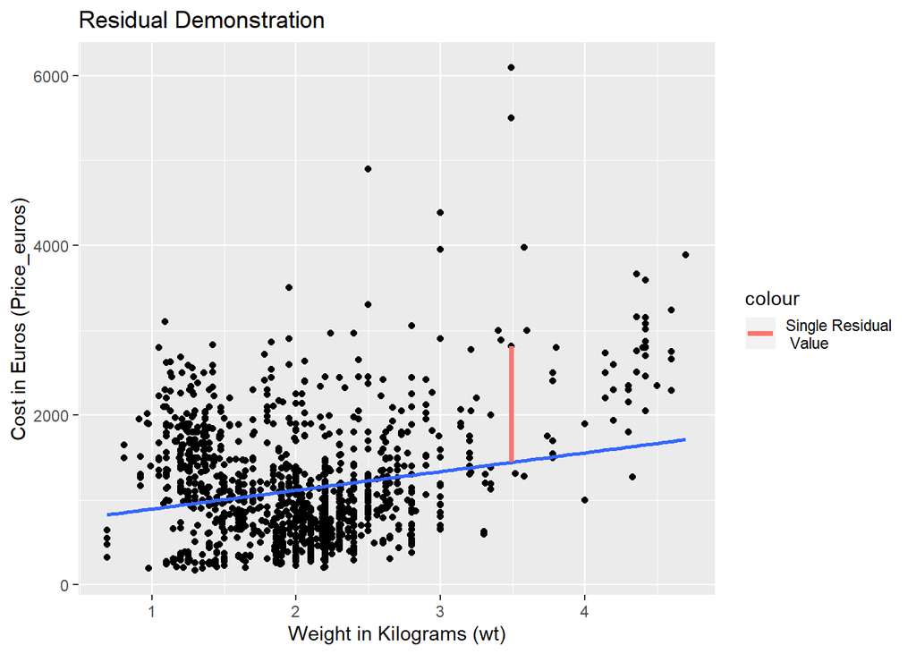

```r
laptp <- Laptop %>% mutate(wt = parse_number(Weight))
first.lm <- lm(Price_euros ~ wt, data = laptp)
fs <- data.frame(x1 = 3.49, y1 = 1444.374, x2 = 3.49, y2 = 2813.75)

ggplot(laptp, aes(x = wt, y = Price_euros))+
  geom_point()+
  geom_smooth(method = "lm", se = FALSE)+
  geom_segment(aes(x = x1, y = y1, xend = x2, yend = y2, color = "Single Residual \n Value"), data = fs, size = 1.3)+
  labs(x = "Weight in Kilograms (wt)", y = "Cost in Euros (Price_euros)", title = "Residual Demonstration")
```

A residual provides 4 uses in a regression analysis according to the ‘Residuals and Errors’ under the explanation tab of Simple Linear Regression in the Statistics Notebook. These uses are:

**1) Diagnose the regression assumptions.**

The 5 regression assumptions are

*1. The regression relation between* $Y$ *and* $X$ *is linear*

*2. The error terms are normally distributed with* $E\{\epsilon_i\}=0$

*3. The variance of the error term is constant over all* $X$ *values*

*4. The* $X$ *values can be considered fixed and measured without error*

*5. The error terms are independent*

These assumptions can be examined using the following diagnostic plots, using the same regresison analysis as the above plot:

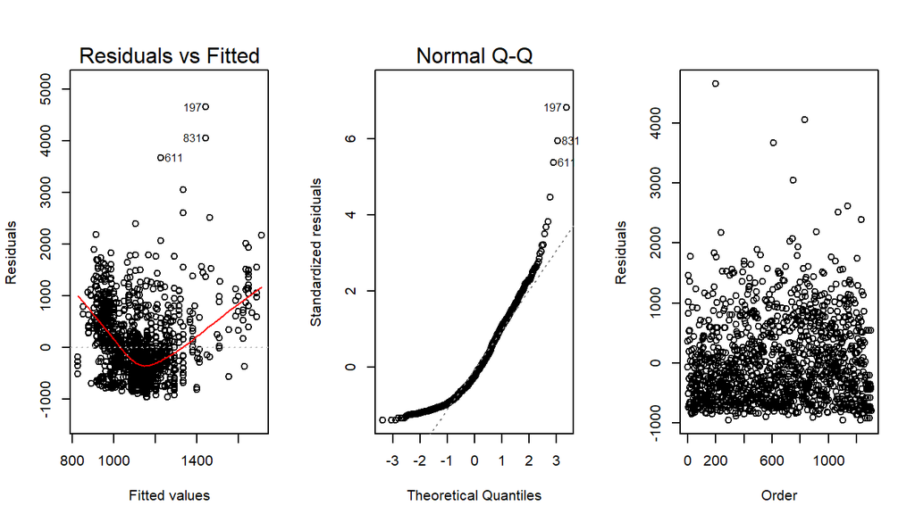

```r
par(mfrow=c(1,3))
plot(first.lm, which=1:2)
plot(first.lm$residuals, xlab = "Order", ylab = "Residuals")
```

The first plot, which shows the residuals vs fitted values, checks for the first and third assumptions. Our plot shows that we do not have a linear relations, due to the fact that the red line is not close to flat. The constant variance seems to check out however, which can be checked using Brother Saunders’ “Pinky-Thumb Rule”, which is an easy way of visualizing whether or not the distances of points from the dashed line tend to increase or decrease when moving from left to right. They do show qhat is cause for a little concern, but this alone would not be enough to disregard the results of a regression analysis.

The second plot shows our residuals on a QQ-Plot. Here we check the second assumption, the normality of the error terms. This plots shows an issue because both tails of the trend are durving away from the dashed line, which is not good. We check this because if the residuals appear to be normally distributed, we assume that the error terms are normally distributed as well. If, however, the residuals do not, the errors are also assumed to not be normally distributed.

The final plot, the residuals vs order plot checks the fifth assumption: that the error terms are independent. A plot that does meet this assumption, will have no clear pattern. It is best to only look at the plot for a few seconds, and if no distinct pattern is discovered, the errors are assumed to be independent. With a residuals vs order plot, we want to see chaos, which is more or less what we see in our plot.

**2) Estimate the regression relation**

This can be most easily understood using the least squares approach. This is an approach where each residual (rememebr, the residual is just a distance, negative or positive, measured from the regression line) is squared, in order to make them all positive. It is important to understood that if they were not squared, and then added all together, the answer would be zero. This is due to the idea that the regression line is the mean of all the points, so the distances above the regresison line will be equal to the distances below the regression line, but since a residual can be negative, they would cancel out. Once the residuals are squared, the areas are added together. The regression line represents the line where the sum of these areas, or squares, is the smallest it can be with the given data. Thus, a smaller sum of squares means the dots are closer to the regresison line, which means a larger correlation, which will be discussed later.

**3) Estimate the variance of the error terms**

This is where we use $MSE$ (Mean Squared Error) to estimate $\sigma_i$. The mean of squared error uses the errors of $Y_i-\hat{Y_i}$, squares them as the name denotes, and then divides by their degrees of freedom, which is $n-2$.

**4) Assess the fit of the regression relation**

The fit of the regression relation can be visualized to be how close (with regards to Y) each point is to the regression line, so when the residuals are smaller, the regression model is a better fit for the true line.

## Question 2

**What are each of SSTO, SSR, and SSE? How are they related? How do they differ? Find a way to both show and explain these values. How are they used to gain insight about data with a regression analysis?**

*It is important to note that in the following plot, the point that was chosen to demonstrate these concepts was enlarged, and that the line segments demonstrating each individual value were adjusted with regards to the x-axis to be clearly visible next to each other. The dashed line represents* $\bar{Y}$.

**SSE** stands for the Sum of Squared Errors. It measures the deviance of the residuals from the regression line. It can be defined as the amount of variation left from $\bar{Y}$ after our regression line is incorporated. It is depicted in the below graph by the red line. It is important to understand however, that this one value is not $SSE$, it is just a demonstration of the measurement for one point that I chose to be able to deomonstrate clearly these values. $SSE$ is calculated by squaring all of the red distances (a residual) for each point, and then adding them together. It can be modeled as:
$$SSE = \sum_{i=1}^n(Y_i-\hat{Y_i})^2$$
The description of a residual can be found earlier in this document.

**SSR** stands for the Sum of Squares Regression. It measures the deviation of the regresison line from the average value of Y, which can be depicted as the sum:
$$SSR = \sum_{i=1}^n(\hat{Y_I}-\bar{Y})^2$$

It is shown on the graph as the green line. Again, this single distance is not equal to $SSR$, but is simply a demonstration of how it is measured for each point. $SSR$ can be defined as the amount of variability that the regression line has explained.

**SSTO** is the Total Sum of Squares. It measures the deviation of the y- values from the average y-value, as shown in blue on the below graph. It can clearly be seen, that a simple formula for finding $SSTO$ is $SSE+SSR$ , however a more complete formula is:
$$SSTO = \sum_{i=1}^n(Y_i-\bar{Y_i})^2$$

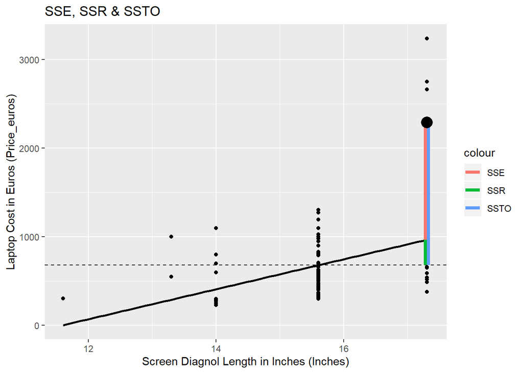

```r
laptopIn.lm <- lm(Price_euros ~ Inches, data = idp2)

ep = data.frame(Inches = 17.3, Price_euros = 2289.99)
sse <- data.frame(x1 = 17.275, y1 = 966.6638, x2 = 17.275, y2 = 2289.99)
ssr <- data.frame(x1 = 17.275, y1 = mean(idp2$Price_euros), x2 = 17.275, y2 = 966.6638)
ssto <- data.frame(x1 = 17.325, y1 = mean(idp2$Price_euros), x2 = 17.325, y2 = 2289.99)

ggplot(idp2, aes (x = Inches, y = Price_euros))+
  geom_point(col = "black", pch = 19)+
  geom_hline(yintercept = mean(idp2$Price_euros), linetype = "dashed")+
  geom_smooth(method = "lm", se = FALSE, col = "black")+
  labs(x = "Screen Diagnol Length in Inches (Inches)", y = "Laptop Cost in Euros (Price_euros)", title = "SSE, SSR & SSTO")+
  geom_segment(aes(x = x1, y = y1, xend = x2, yend = y2, color = "SSE"), data = sse, size = 1.5)+
  geom_segment(aes(x = x1, y = y1, xend = x2, yend = y2, color = "SSR"), data = ssr, size = 1.5)+
  geom_segment(aes(x = x1, y = y1, xend = x2, yend = y2, color = "SSTO"), data = ssto, size = 1.5)+
  geom_point(data = ep, pch = 19, size = 5, col = "black")
```

These values of $SSE$, $SSR$, and $SSTO$ are essential in determining the correlation of a regression line. As will be shown later, the coefficient of variation is equal to $\frac{SSR}{SSTO}$.

The actual values of these three sums will be computed for the above regression:

```r
rbind(SSE=sum(laptopIn.lm$residuals^2),
      SSR =sum((laptopIn.lm$fitted - mean(idp2$Price_euros))^2),
      SSTO = sum((idp2$Price_euros - mean(idp2$Price_euros))^2)) %>%
  pander(caption= "SS's for the Price on Inches Regression")
```

SS’s for the Price on Inches Regression

| **SSE** | 20867846 |
| --- | --- |
| **SSR** | 3197560 |
| **SSTO** | 24065407 |

It can here be observed that $SSE + SSR = SSTO$: $20867846+3197560=24065407$ with a margin for rounding error.

## Question 3

**What is R-squared? How is it properly interpreted? How is it calculated? What information does it provide about a regression analysis? How does it differ from the information provided in the p-value for the slope term? How does it relate to the residual standard error?**

As previsouly mentioned, $R^2=\frac{SSR}{SSTO}$, which is then the proportion of the total variability in $Y$ that the regression line explains. It demonstrates how different the regression line, $\hat{Y}$ is from $\bar{Y}$, which has a slope of 0. It differs from the p-value for the slope term because if the $SSR$ was a small propotion of $SSTO$, which would result in a small $R^2$ value, we could still have a significant p-value for our slope term if we had, for example, a very large sample size. The residual standard error is equal to $\sqrt{MSE}$ similar to the average distance a point is from the regression line, but instead of dividing the sum by $n$, it is divided by $n-2$. The $MSE$ estimates the true value of $\sigma^2$, and is calculated as $\frac{SSE}{n-p}$ where $n-p=\text{Degrees of freedom}$ and $p = \text{the number of paramters being estimated}$. If we were just given the summary() output of a regression model, to find the SSE, we would first square the residual standard error, and then multiply it by the degrees of freedom.

This relationship is demonstrated here, using the summary output of the above regression. Notice how to calculated $SSE$ value nearly exactly corresponds to the $SSE$ value shown above:

```r
summary(laptopIn.lm) %>% pander()
```

|  | Estimate | Std. Error | t value | Pr(>\|t\|) |
| --- | --- | --- | --- | --- |
| **(Intercept)** | -1958 | 669.1 | -2.927 | 0.004225 |
| **Inches** | 169.1 | 42.77 | 3.953 | 0.0001423 |

Fitting linear model: Price_euros ~ Inches

| Observations | Residual Std. Error | $R^2$ | Adjusted $R^2$ |
| --- | --- | --- | --- |
| 104 | 452.3 | 0.1329 | 0.1244 |

```r
(452.3^2)*102
```

```
## [1] 20866680
```

The $R^2$ value for the above regression model is calculated here:

```r
(sum((laptopIn.lm$fitted - mean(idp2$Price_euros))^2))/ sum((idp2$Price_euros - mean(idp2$Price_euros))^2)
```

```
## [1] 0.1328696
```

In the early 1900’s, Karl Pearson was trying to come up with a way to measure how close a line approximated a set of points. His method was to divide the dataset into four quadrants, where the x and y axes are $\bar{X}$ and $\bar{Y}$ as such:

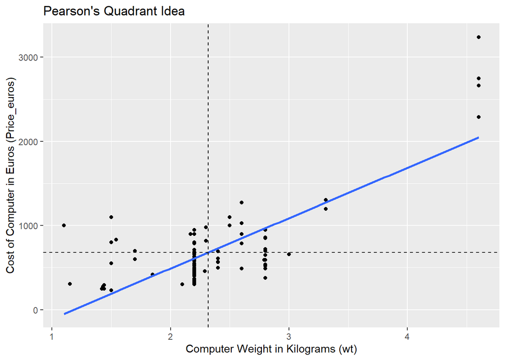

Pearson concluded that if the majority of data points landed in the first and third quadrants, as they do in this plot, then there would be a positive correlation between the points, and that if the majority of dots landed in the second and fourth quadrants, there would be a negative correlation. This was the early development of $r$ and $R^2$. The mathematical formula for the correlation is also included, for those interested:

$$r = \frac{\textstyle\sum\left(\frac{x-\bar{x}}{s_x}\right)\left(\frac{y-\bar{y}}{s_y}\right)}{n-1}$$